# Differential module eigengene (DME) analysis

TigerZ

2023-5-4

在本教程中，我们将演示如何执行差模本征基因（DME）分析，揭示在给定细胞组中上调或下调的模块。

首先，我们加载通过基础教程处理的单细胞数据集和本教程所需的 R 库。

```r
# single-cell analysis package
library(Seurat)

# plotting and data science packages
library(tidyverse)
library(cowplot)
library(patchwork)
library(ggrepel)

# co-expression network analysis packages:
library(WGCNA)
library(hdWGCNA)

# using the cowplot theme for ggplot
theme_set(theme_cowplot())

# set random seed for reproducibility
set.seed(12345)

# 导入之前分析的结果
seurat_obj <- readRDS('hdWGCNA_object.rds')
```

# 1 DME analysis comparing two groups

在这里，我们讨论如何在两个不同的组之间进行 DME 测试。我们使用 hdWGCNA 函数 `FindDMEs`，它是 Seurat 函数 `FindMarkers` 的一个特例。我们使用 Mann-Whitney U 检验，也称为 Wilcoxon 检验，来比较两组，但用户可以自行决定使用 `test.use` 参数使用其他检验。

由于教程数据集仅包含对照脑样本，因此我们将使用性别来定义我们的两组。`FindDMEs` 需要 group1 和 group2 的条形码列表。此外，我们只比较 INH 簇中的细胞，因为这是我们进行网络分析的组。

```r
group1 <- seurat_obj@meta.data %>% subset(cell_type == 'INH' & msex == 0) %>% rownames
group2 <- seurat_obj@meta.data %>% subset(cell_type == 'INH' & msex != 0) %>% rownames

head(group1)
```

```
[1] "TCTTCGGCAAGACGTG-11" "ATTATCCGTTGATTCG-11" "CCACCTAGTCCAAGTT-11"
[4] "AGCGTATGTTAAGAAC-11" "GTAACTGTCCAGATCA-11" "CGATTGATCTTTACAC-11"
```

接下来，我们运行 `FindDME` 函数

```r
DMEs <- FindDMEs(
  seurat_obj,
  barcodes1 = group1,
  barcodes2 = group2,
  test.use='wilcox',
  wgcna_name='tutorial'
)
```

```
[1] 36671    20
 [1] "INH-M1"  "INH-M2"  "INH-M3"  "INH-M4"  "INH-M5"  "INH-M6"  "INH-M7"  "INH-M8"
 [9] "INH-M9"  "INH-M10" "INH-M11" "INH-M12" "INH-M13" "INH-M14" "INH-M15" "INH-M16"
[17] "INH-M17" "INH-M18" "INH-M19" "INH-M20"
```

```r
head(DMEs)
```

|  | p_val | avg_log2FC | pct.1 | pct.2 | p_val_adj | module |
| --- | --- | --- | --- | --- | --- | --- |
| INH-M2 | 4.546653e-31 | 0.52068874 | 0.843 | 0.620 | 9.093306e-30 | INH-M2 |
| INH-M20 | 1.579993e-07 | -0.23249761 | 0.718 | 0.806 | 3.159985e-06 | INH-M20 |
| INH-M16 | 4.318808e-06 | -0.17026642 | 0.830 | 0.922 | 8.637617e-05 | INH-M16 |
| INH-M17 | 5.843479e-06 | -0.17083863 | 0.812 | 0.908 | 1.168696e-04 | INH-M17 |
| INH-M4 | 1.728991e-04 | -0.07420588 | 0.968 | 0.979 | 3.457982e-03 | INH-M4 |
| INH-M11 | 5.243937e-03 | -0.09532684 | 0.956 | 0.969 | 1.048787e-01 | INH-M11 |

```r
PlotDMEsLollipop(
  seurat_obj,
  DMEs,
  wgcna_name='tutorial',
  pvalue = "p_val_adj"
)
```

[output not shown]

对于`PlotDMEsLollipop`，如果我们在 DMEs 数据框中有其他自定义列，我们可以使用 `group.by` 参数提供列名和比较参数，用于一个比较组或一组比较组的列表进行绘图。例如：

```r
PlotDMEslollipop(
  seurat_obj,
  DMEs,
  wgcna_name='tutorial',
  group.by = "Comparisons",
  comparison = c("group1_vs_control", "group2_vs_control"),
  pvalue = "p_val_adj"
)
```

接下来，我们使用`PlotDMEsVolcano`制作一个火山图，将效果大小和显著性级别一起显示出来。

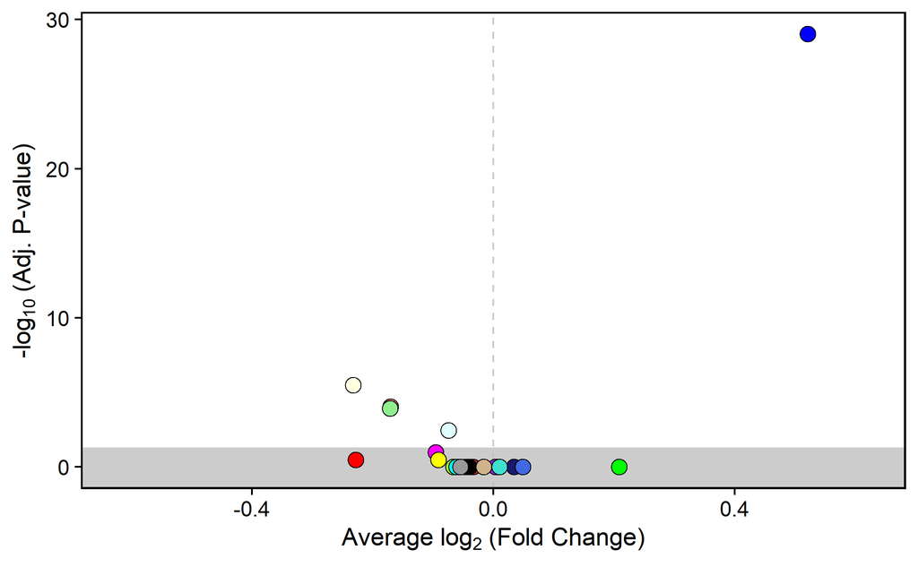

```r
PlotDMEsVolcano(
  seurat_obj,
  DMEs,
  wgcna_name = 'tutorial'
)
```

# 2 One-versus-all DME analysis

类似于 Seurat 函数 `FindAllMarkers`，当指定一个列来分组细胞时，我们可以使用函数 `FindAllDMEs` 进行一对所有的 DME 测试。在这里，我们将 `group.by` 每个细胞类型进行一对所有测试。

```r
group.by = 'cell_type'

DMEs_all <- FindAllDMEs(
  seurat_obj,
  group.by = 'cell_type',
  wgcna_name = 'tutorial'
)
```

```
[1] "EX"
[1] "INH"
[1] "ASC"
[1] "OPC"
[1] "MG"
[1] "ODC"
```

```r
head(DMEs_all)
```

[output not shown]

输出看起来类似于 `FindDME`，但有一个称为 `group` 的额外列，其中包含每个细胞分组的信息。

现在我们可以用 `PlotDMEsVolcano` 绘制结果

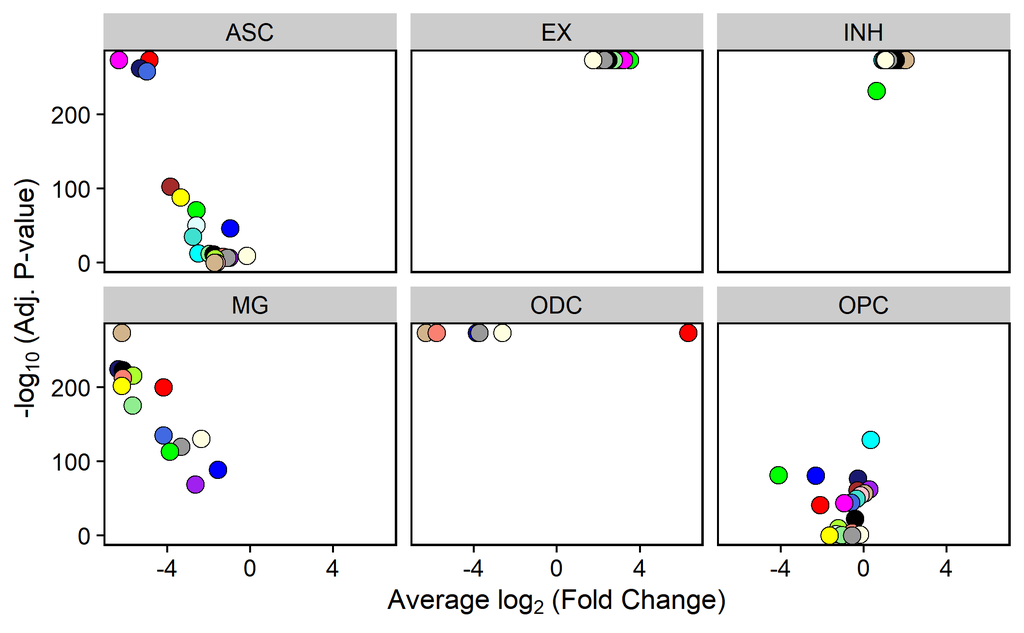

```r
p <- PlotDMEsVolcano(
  seurat_obj,
  DMEs_all,
  wgcna_name = 'tutorial',
  plot_labels=FALSE,
  show_cutoff=FALSE
)

# facet wrap by each cell type
p + facet_wrap(~group, ncol=3)
```